# Usage Guide

# Introduction

This vignette demonstrates how to use the Gene Expression Clustering package for comprehensive analysis of gene expression data. The package provides a complete workflow for:

- Loading and preprocessing gene expression data
- Data normalization and quality control
- Exploratory data analysis with outlier detection
- Multiple clustering methods for gene grouping
- Rich visualization tools for results interpretation
- Gene set enrichment analysis (GSEA) for biological insights

## Installation and Setup

```r
# Load required packages
library(GeneExprClust)
library(Biobase)
library(ggplot2)
library(ComplexHeatmap)

# Set random seed for reproducibility
set.seed(123)
```

# 1. Data Loading and Preprocessing

## 1.1 Loading Expression Data

The package supports multiple input formats including CSV, TSV, and Bioconductor ExpressionSet objects.

```r
# Example 1: Loading from CSV file
# eset <- read_expression("path/to/your/data.csv", type = "csv",
#                        pheno_data = "path/to/sample_metadata.csv")

# Example 2: Creating sample data for demonstration
# Generate example expression data (1000 genes, 20 samples)
n_genes <- 1000
n_samples <- 20

# Create expression matrix with some structure
expr_matrix <- matrix(rnorm(n_genes * n_samples, mean = 8, sd = 2),
                      nrow = n_genes, ncol = n_samples)

# Add some structured patterns for clustering
# Cluster 1: High expression in first 10 samples
expr_matrix[1:200, 1:10] <- expr_matrix[1:200, 1:10] + 3

# Cluster 2: High expression in last 10 samples
expr_matrix[201:400, 11:20] <- expr_matrix[201:400, 11:20] + 2.5

# Cluster 3: Oscillating pattern
for(i in 401:600) {
  expr_matrix[i, ] <- expr_matrix[i, ] + 2 * sin(seq(0, 2*pi, length.out = n_samples))
}

# Add gene and sample names
rownames(expr_matrix) <- paste0("Gene_", sprintf("%04d", 1:n_genes))
colnames(expr_matrix) <- paste0("Sample_", sprintf("%02d", 1:n_samples))

# Create sample metadata
sample_data <- data.frame(
  condition = factor(rep(c("Control", "Treatment"), each = 10)),
  time_point = factor(rep(c("T1", "T2", "T3", "T4"), times = 5)),
  batch = factor(rep(c("Batch1", "Batch2"), times = 10)),
  row.names = colnames(expr_matrix)
)

# Create ExpressionSet
eset <- ExpressionSet(
  assayData = expr_matrix,
  phenoData = AnnotatedDataFrame(sample_data)
)

print(eset)
```

```
#> ExpressionSet (storageMode: lockedEnvironment)
#> assayData: 1000 features, 20 samples
#>   element names: exprs
#> protocolData: none
#> phenoData
#>   sampleNames: Sample_01 Sample_02 ... Sample_20 (20 total)
#>   varLabels: condition time_point batch
#>   varMetadata: labelDescription
#> featureData: none
#> experimentData: use 'experimentData(object)'
#> Annotation:
```

## 1.2 Data Overview

```r
# Basic information about the dataset
message("Number of genes: ", nrow(eset))
message("Number of samples: ", ncol(eset))
message("Sample conditions: ", table(pData(eset)$condition))

# Expression data summary
summary(exprs(eset)[1:5, 1:5])
```

```
#>    Sample_01        Sample_02        Sample_03        Sample_04
#>  Min.   : 9.879   Min.   : 5.901   Min.   : 9.917   Min.   : 8.104
#>  1st Qu.:10.540   1st Qu.: 8.920   1st Qu.: 9.977   1st Qu.: 9.605
#>  Median :11.141   Median : 9.008   Median :11.348   Median :10.344
#>  Mean   :11.387   Mean   : 9.106   Mean   :11.231   Mean   :10.990
#>  3rd Qu.:11.259   3rd Qu.:10.736   3rd Qu.:11.474   3rd Qu.:10.699
#>  Max.   :14.117   Max.   :10.964   Max.   :13.438   Max.   :16.197
#>    Sample_05
#>  Min.   : 6.948
#>  1st Qu.: 8.432
#>  Median :11.393
#>  Mean   :10.283
#>  3rd Qu.:12.300
#>  Max.   :12.342
```

# 2. Data Normalization and Quality Control

## 2.1 Data Normalization

The package supports multiple normalization methods including log2 transformation, quantile normalization, z-score standardization, and DESeq2 normalization.

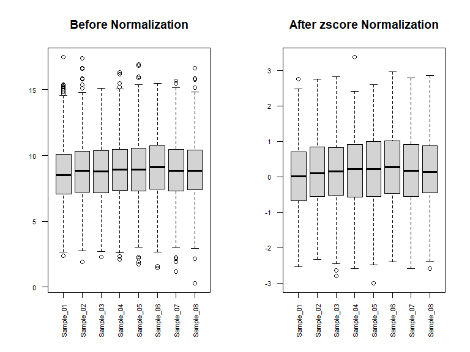

```r
# Apply log2 normalization with optional filtering
eset_norm <- normalize_data(
  eset,
  method = "zscore",
  filter = TRUE,
  filter_threshold = 1,
  filter_min_samples = 3
)

message("Genes after filtering: ", nrow(eset_norm))

# Compare before and after normalization
par(mfrow = c(1, 2))
boxplot(exprs(eset)[, 1:8], main = "Before Normalization",
        las = 2, cex.axis = 0.7)
boxplot(exprs(eset_norm)[, 1:8], main = "After zscore Normalization",
        las = 2, cex.axis = 0.7)
```

## 2.2 Batch Effect Correction (Optional)

```r
# If batch effects are present, correct them
eset_batch_corrected <- normalize_data(
  eset_norm,
  method = "zscore",
  batch = "batch"  # Column name in phenotype data
)
```

# 3. Exploratory Data Analysis

## 3.1 Principal Component Analysis

```r
# PCA plot to visualize sample relationships
pca_plot <- plot_pca(eset_norm, color_by = "condition",
                     main = "PCA: Samples Colored by Condition")
message(pca_plot)
```

[output not shown]

## 3.2 Outlier Gene Detection

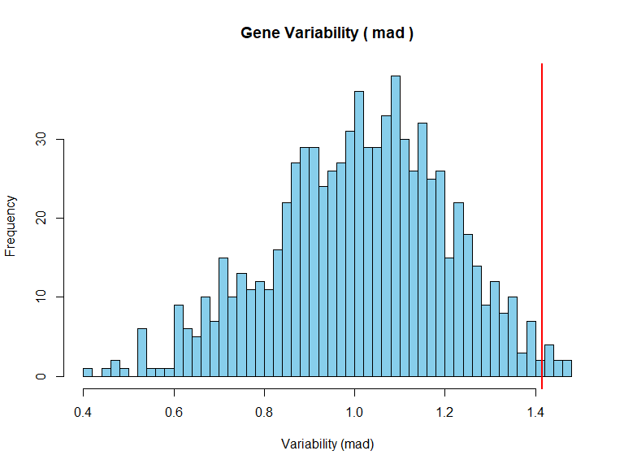

```r
# Detect outlier genes based on variability
eset_clean <- detect_outliers(
  eset_norm,
  method = "mad",
  threshold = 3,
  plot = TRUE,
  remove = TRUE
)
```

```r
message("Outlier genes detected and removed:",
    length(attr(eset_clean, "outliers")))
```

# 4. Gene Clustering Analysis

## 4.1 Determining Optimal Number of Clusters

```r
# Elbow plot for k-means
elbow_plot <- plot_elbow(eset_clean, max_k = 15, target = "gene")
message(elbow_plot)

# Gap statistic analysis
gap_results <- gap_statistic(t(exprs(eset_clean)), max_k = 12, B = 20)
print(head(gap_results))
```

```
#>       logW   E.logW          gap     SE.sim
#> 1 5.229031 5.250319  0.021287634 0.02997765
#> 2 5.080515 5.144106  0.063591452 0.03256746
#> 3 5.020101 5.048281  0.028180040 0.03550051
#> 4 4.953637 4.955292  0.001655653 0.03875645
#> 5 4.885962 4.867866 -0.018095777 0.03828962
#> 6 4.813897 4.772098 -0.041798355 0.04060960
```

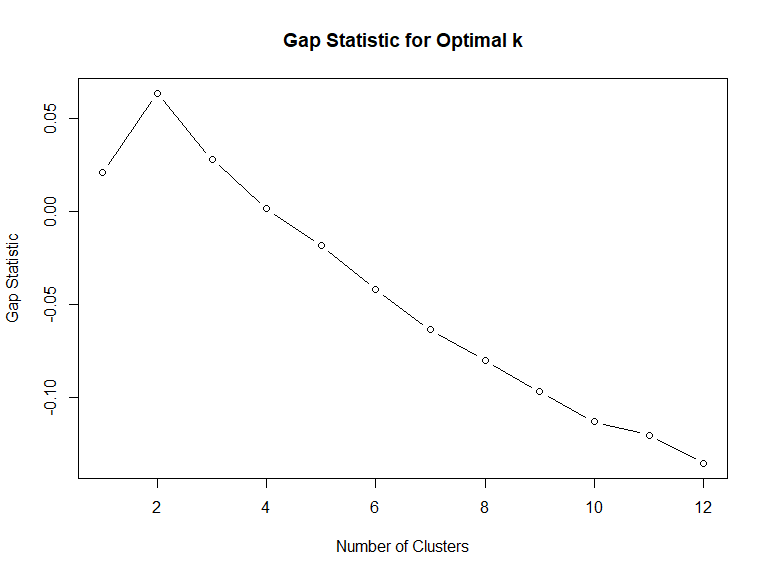

```r
# Plot gap statistic
plot(1:nrow(gap_results), gap_results$gap, type = "b",
     xlab = "Number of Clusters", ylab = "Gap Statistic",
     main = "Gap Statistic for Optimal k")
```

## 4.2 Hierarchical Clustering

```r
# Perform hierarchical clustering
hc_result <- cluster_expression(
  eset_clean,
  method = "hierarchical",
  k = 5,
  target = "gene",
  hclust_method = "ward.D2",
  distance = "euclidean"
)

# Plot dendrogram
dendrogram_plot <- plot_dendrogram(hc_result$model, main = "Gene Hierarchical Clustering")
message(dendrogram_plot)

# Show cluster sizes
table(hc_result$clusters)
```

```
#>
#>   1   2   3   4   5
#> 314 130  86  94 154
```

## 4.3 K-means Clustering

```r
# Perform k-means clustering
kmeans_result <- cluster_expression(
  eset_clean,
  method = "kmeans",
  k = 5,
  target = "gene",
  nstart = 25
)

# Show cluster sizes
table(kmeans_result$clusters)
```

```
#>
#>   1   2   3   4   5
#> 127 176 170 136 169
```

```r
# Compare clustering methods
comparison_table <- table(
  Hierarchical = hc_result$clusters,
  KMeans = kmeans_result$clusters
)
print(comparison_table)
```

```
#>             KMeans
#> Hierarchical   1   2   3   4   5
#>            1  12 148   0  13 141
#>            2  42   7   9  59  13
#>            3  35  18   1  17  15
#>            4  27   3  27  37   0
#>            5  11   0 133  10   0
```

# 5. Cluster Validation

## 5.1 Clustering Quality Metrics

```r
# Calculate Within-Cluster Sum of Squares (WSS)
wss_hc <- wss_score(exprs(eset_clean), hc_result$clusters)
wss_kmeans <- wss_score(exprs(eset_clean), kmeans_result$clusters)

message("WSS - Hierarchical: ", round(wss_hc, 2))
message("WSS - K-means: ", round(wss_kmeans, 2))

# Calculate Silhouette scores
sil_hc <- silhouette_score(exprs(eset_clean), hc_result$clusters)
sil_kmeans <- silhouette_score(exprs(eset_clean), kmeans_result$clusters)

message("Average Silhouette - Hierarchical: ", round(mean(sil_hc[, 3]), 3))
message("Average Silhouette - K-means: ", round(mean(sil_kmeans[, 3]), 3))
```

# 6. Visualization of Clustering Results

## 6.1 Expression Heatmap

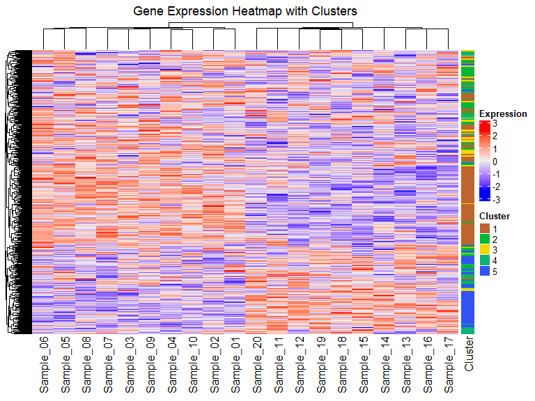

```r
# Create heatmap with cluster annotations
# Use hierarchical clustering results for demonstration
heatmap_plot <- plot_heatmap(
  eset_clean,
  clusters = hc_result$clusters,
  show_row_names = FALSE,
  scale = "row",
  main = "Gene Expression Heatmap with Clusters"
)

print(heatmap_plot)
```

## 6.2 Cluster Expression Profiles

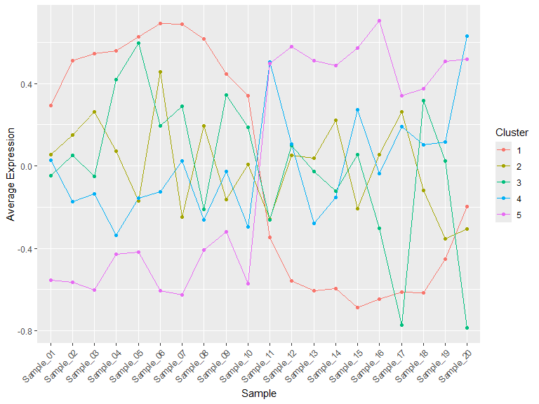

```r
# Plot average expression profiles per cluster
profile_plot <- plot_cluster_profiles(
  eset_clean,
  clusters = hc_result$clusters,
  scale = TRUE
)
print(profile_plot)
```

## 6.3 Individual Cluster Heatmaps

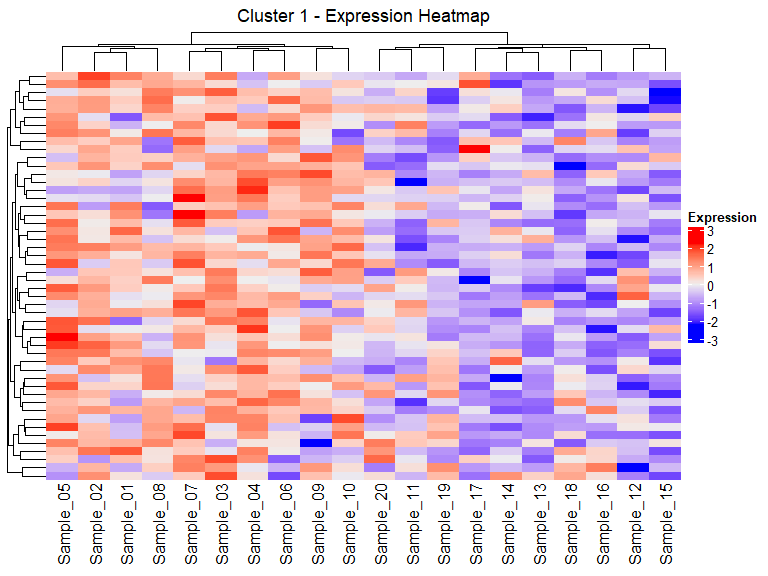

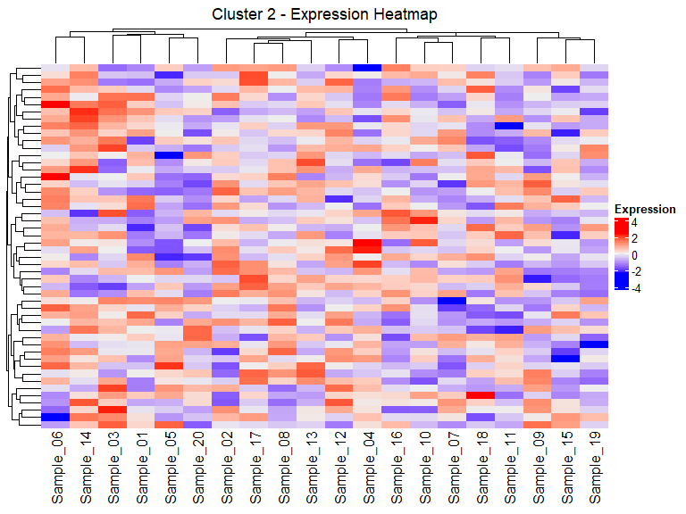

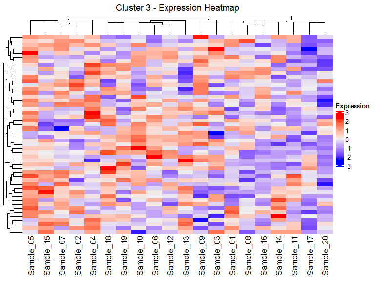

```r
# Focus on specific clusters
for(cluster_id in 1:3) {
  cluster_genes <- names(hc_result$clusters)[hc_result$clusters == cluster_id]

  if(length(cluster_genes) > 50) {
    cluster_genes <- sample(cluster_genes, 50)  # Sample for visualization
  }

  cluster_eset <- eset_clean[cluster_genes, ]

  heatmap_cluster <- plot_heatmap(
    cluster_eset,
    show_row_names = FALSE,
    scale = "row",
    main = paste("Cluster", cluster_id, "- Expression Heatmap")
  )

  print(heatmap_cluster)
}
```